# PracticaFinal

*— Ventas y conce:*

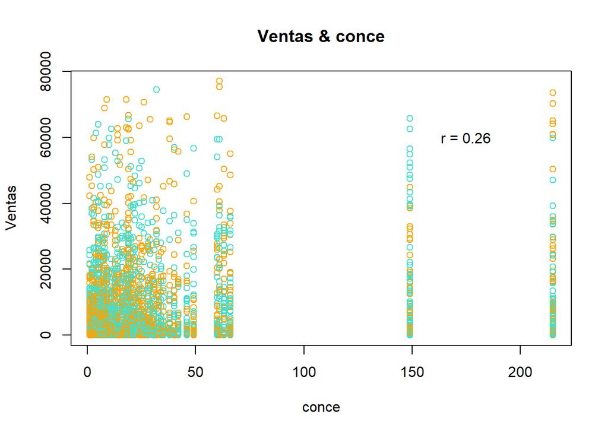

```r
cor_coef15 = cor(practica$conce,practica$VENTAS, method = "spearman")
plot(x = practica$conce, y = practica$VENTAS, main = "Ventas & conce", xlab = "conce", ylab = "Ventas", pch = 1, col = c("orange", "turquoise"))
text(175, 60000, glue::glue ("r = {round (cor_coef15, 2)}"))
```

Correlación positiva débil pero significativa entre ventas y conce. Se suele pensar que a menor competencia más se incrementarían las ventas de las tiendas, y en este caso no ocurre así, puesto que la correlación arroja un valor no muy alto (0.26).

*— Ventas y numac:*

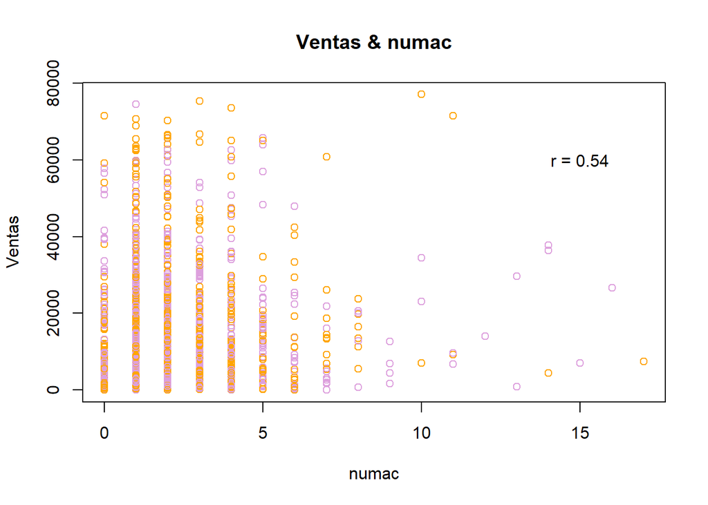

```r
cor_coef16 = cor(practica$numac,practica$VENTAS, method = "spearman")
plot(x = practica$numac, y = practica$VENTAS, main = "Ventas & numac", xlab = "numac", ylab = "Ventas", pch = 1, col = c("orange", "plum"))
text(15, 60000, glue::glue ("r = {round (cor_coef16, 2)}"))
```

Se observa correlación positiva y significativa entre las ventas y el nº de accionistas de las tiendas, con un valor de 0.54

*— Ventas y numpa:*

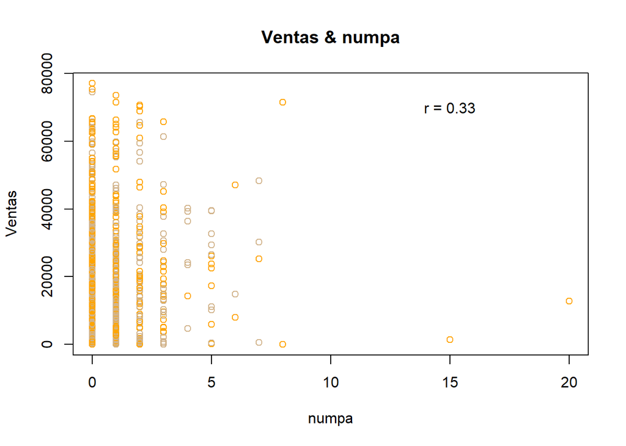

```r
cor_coef17 = cor(practica$numpa,practica$VENTAS, method = "spearman")
plot(x = practica$numpa, y = practica$VENTAS, main = "Ventas & numpa", xlab = "numpa", ylab = "Ventas", pch = 1, col = c("orange", "tan"))
text(15, 70000, glue::glue ("r = {round (cor_coef17, 2)}"))
```

Hay correlación positiva débil y significativa entre ventas y el nº de participados. Como la correlación entre ventas y el numac es mayor que entre ventas y numpa, puede pensarse que se podría prescindir de numpa para nuestro modelo predictivo.

*— Ventas y numest:*

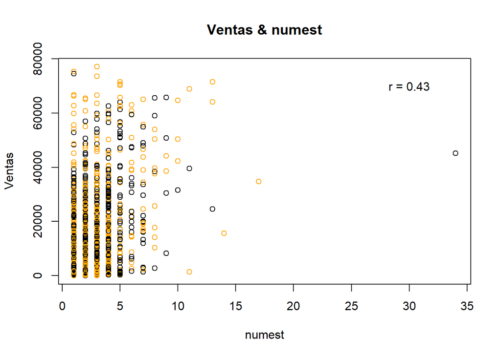

```r
cor_coef18 = cor(practica$numest,practica$VENTAS, method = "spearman")
plot(x = practica$numest, y = practica$VENTAS, main = "Ventas & numest", xlab = "numest", ylab = "Ventas", pch = 1, col = c("orange", "black"))
text(30, 70000, glue::glue ("r = {round (cor_coef18, 2)}"))
```

Hay correlación positiva y significativa entre ventas y el nº de establecimientos por empresa con un valor de correlación de 0.43.

**Continuamos nuestro análisis con las variables categóricas:**

*— Ventas y Estp:*

```r
wilcox.test(VENTAS ~ estp, practica)
```

```
##
##  Wilcoxon rank sum test with continuity correction
##
## data:  VENTAS by estp
## W = 146090, p-value < 2.2e-16
## alternative hypothesis: true location shift is not equal to 0
```

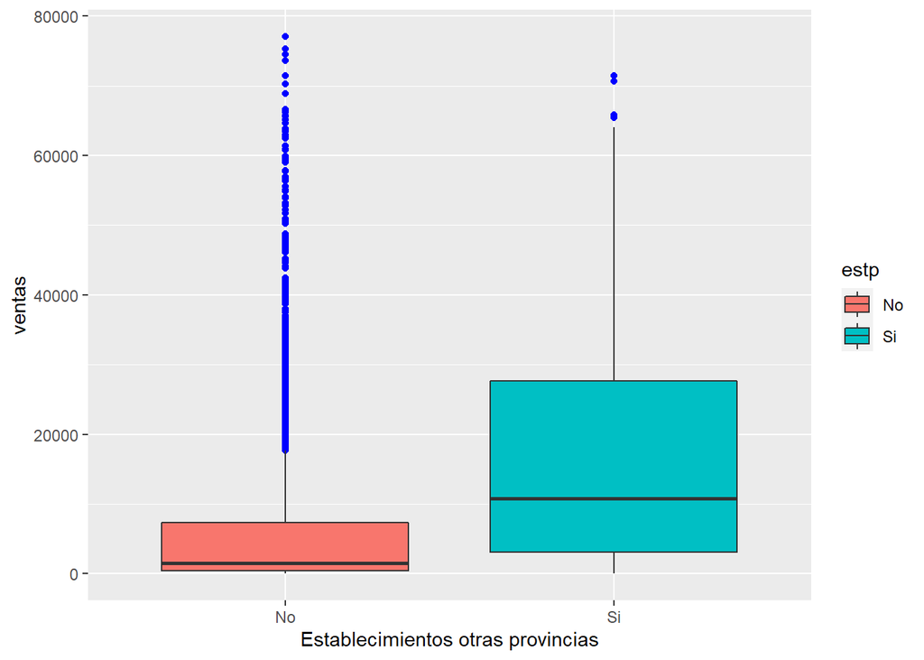

```r
ggplot(practica, aes(estp, VENTAS, fill = estp)) +
  geom_boxplot(outlier.colour = "blue") +
  labs(x="Establecimientos otras provincias", y="ventas", fill="estp")
```

El gráfico refleja que las franquicias con tiendas fuera de sus provincias, vende más. Ahora bien, como vimos, el número de franquicias con tiendas fuera de sus provincias es muy bajo, por lo que puede nos ser una variable reseñable a la hora de confeccionar nuestra predicción.

*— Ventas y Grupos Provincias:*

```r
kruskal.test(VENTAS ~ GRUPOS_PROVINCIAS, practica)
```

```
##
##  Kruskal-Wallis rank sum test
##
## data:  VENTAS by GRUPOS_PROVINCIAS
## Kruskal-Wallis chi-squared = 15.327, df = 5, p-value = 0.009053
```

```r
kruskal.test(VENTAS ~ PROVINCIA, datosPractica)
```

```
##
##  Kruskal-Wallis rank sum test
##
## data:  VENTAS by PROVINCIA
## Kruskal-Wallis chi-squared = 60.013, df = 51, p-value = 0.1815
```

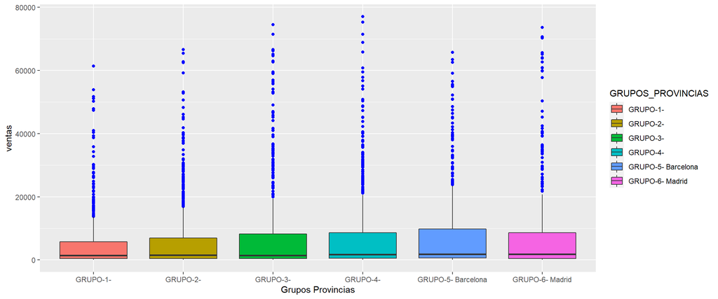

```r
ggplot(practica, aes(GRUPOS_PROVINCIAS, VENTAS, fill = GRUPOS_PROVINCIAS)) +
  geom_boxplot(outlier.colour = "blue") +
  labs(x="Grupos Provincias", y="ventas", fill="GRUPOS_PROVINCIAS")
```

Es apreciable la cantidad importante de outliers en la muestra, si bien entiendo eliminarlos no seria buena opción, puesto que reduciría demasiado el tamaño de la muestra.

Si tuviésemos en cuenta los datos iniciales por Provincias, y según datos del test, no existiría diferencias significativas entre las ventas y las provincias donde se encuentren las franquicias.

Ahora bien, según la agrupación que hicimos por tamaño de provincias, podemos observar que las ventas no experimentan una subida significativa para los grupos de provincias con mayor número de habitantes, es más, grupos como el de Madrid se asemeja mucho a los grupos 3 y 4 en ventas.

##### **3. Realizar una tabla de contingencia entre Ventas y Número de empleados, una vez categorizadas ambas variables, para número de empleados, por ejemplo, la utilizada a nivel Europeo, la cual divide a las empresas en Microempresas (1-9 trabajadores), Pequeña empresa (10-49 trabajadores), Mediana empresa (50-249 trabajadores) y Gran empresa (250 y más trabajadores)).**

**Categorizamos la varible VENTAS:**

Para ello considero como valores de corte el dato de los cuartiles y mediana de las ventas.

```r
summary(practica$VENTAS)
```

```
##     Min.  1st Qu.   Median     Mean  3rd Qu.     Max.
##     4.92   494.89  1592.14  6648.16  7819.91 77055.79
```

```r
Ventas <- cut(practica$VENTAS, breaks = c(0, 495, 1593, 7820, Inf), labels = c("Ventas Bajas", "Ventas Medias", "Ventas Medias-Altas", "Ventas Altas"))
summary(Ventas)
```

```
##        Ventas Bajas       Ventas Medias Ventas Medias-Altas        Ventas Altas
##                1101                1101                1100                1101
```

**Categorizamos la varible Nº de Empleados:**

No categorizo por Gran Empresa al no tener valores para esta categoría.

```r
Tamaño <- cut(practica$NºEmp, breaks = c(0, 9, 49, 249), labels = c("Microempresas", "Pequeña Empresa", "Mediana Empresa"))
summary(Tamaño)
```

```
##   Microempresas Pequeña Empresa Mediana Empresa
##            2561            1501             341
```

Nótese que no existen grandes empresas en el estudio.

**Realizamos la tabla de contingencia:**

```r
Ventas_Tamaño <- table(Ventas, Tamaño)
round(prop.table(Ventas_Tamaño) * 100,2)
```

```
##                      Tamaño
## Ventas                Microempresas Pequeña Empresa Mediana Empresa
##   Ventas Bajas                24.48            0.52            0.00
##   Ventas Medias               20.89            4.07            0.05
##   Ventas Medias-Altas         11.65           13.22            0.11
##   Ventas Altas                 1.14           16.28            7.59
```

```r
gmodels::CrossTable(Ventas, Tamaño, chisq.test = T)
```

```
##
##
##    Cell Contents
## |-------------------------|
## |                       N |
## | Chi-square contribution |
## |           N / Row Total |
## |           N / Col Total |
## |         N / Table Total |
## |-------------------------|
##
##
## Total Observations in Table:  4403
##
##
##                     | Tamaño
##              Ventas |   Microempresas | Pequeña Empresa | Mediana Empresa |       Row Total |
## --------------------|-----------------|-----------------|-----------------|-----------------|
##        Ventas Bajas |            1078 |              23 |               0 |            1101 |
##                     |         299.031 |         330.745 |          85.269 |                 |
##                     |           0.979 |           0.021 |           0.000 |           0.250 |
##                     |           0.421 |           0.015 |           0.000 |                 |
##                     |           0.245 |           0.005 |           0.000 |                 |
## --------------------|-----------------|-----------------|-----------------|-----------------|
##       Ventas Medias |             920 |             179 |               2 |            1101 |
##                     |         122.079 |         102.702 |          81.316 |                 |
##                     |           0.836 |           0.163 |           0.002 |           0.250 |
##                     |           0.359 |           0.119 |           0.006 |                 |
##                     |           0.209 |           0.041 |           0.000 |                 |
## --------------------|-----------------|-----------------|-----------------|-----------------|
## Ventas Medias-Altas |             513 |             582 |               5 |            1100 |
##                     |          25.135 |         114.272 |          75.485 |                 |
##                     |           0.466 |           0.529 |           0.005 |           0.250 |
##                     |           0.200 |           0.388 |           0.015 |                 |
##                     |           0.117 |           0.132 |           0.001 |                 |
## --------------------|-----------------|-----------------|-----------------|-----------------|
##        Ventas Altas |              50 |             717 |             334 |            1101 |
##                     |         544.299 |         311.015 |         725.547 |                 |
##                     |           0.045 |           0.651 |           0.303 |           0.250 |
##                     |           0.020 |           0.478 |           0.979 |                 |
##                     |           0.011 |           0.163 |           0.076 |                 |
## --------------------|-----------------|-----------------|-----------------|-----------------|
##        Column Total |            2561 |            1501 |             341 |            4403 |
##                     |           0.582 |           0.341 |           0.077 |                 |
## --------------------|-----------------|-----------------|-----------------|-----------------|
##
##
```

Aquí se muestran las frecuencias absolutas (conteo) y relativas (%) para la relación entre las Ventas y el número de empleados.

Se aprecia que la distribución no es homogénea. Hay alta concentración de microempresas con ventas reducidas.

No hay independencia entre las ventas y el tamaño de las tiendas. Se reafirma la relación positiva entre el tamaño de las franquicias y su nivel de ventas.

```r
chisq.test(Ventas_Tamaño)
```

```
##
##  Pearson's Chi-squared test
##
## data:  Ventas_Tamaño
## X-squared = 2816.9, df = 6, p-value < 2.2e-16
```

Con un nivel de significación de 0.05, podemos rechazar la hipótesis nula, luego consideraremos que hay dependencia entre ambas variables, es decir, el tamaño de empresa está asociado a las Ventas, con un nivel de confianza del 95%.

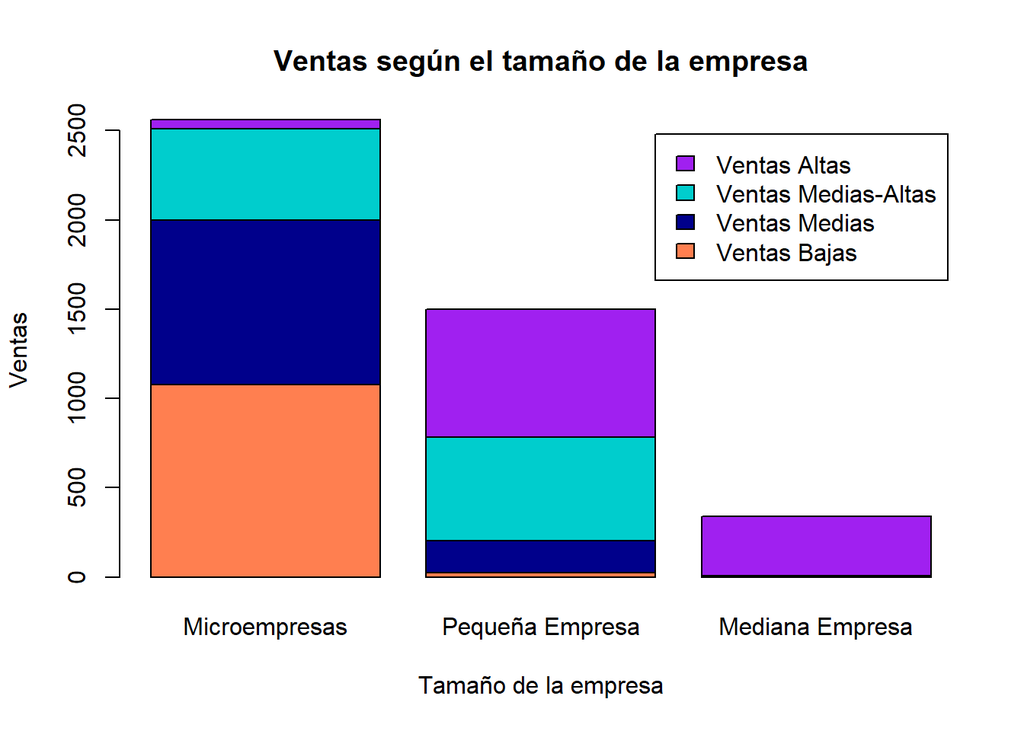

```r
barplot(Ventas_Tamaño,
        main = "Ventas según el tamaño de la empresa",
        xlab="Tamaño de la empresa", ylab="Ventas",
        col = c("coral", "darkblue", "cyan3", "purple"),
        legend.text = rownames(Ventas_Tamaño),
        beside = FALSE)
```

##### **4. Comparar las ventas entre Madrid y Barcelona.**

Primero veamos si las ventas se comportan de forma distinta entre Madrid y Barcelona.

```r
datos_Madrid <-
  filter( practica, GRUPOS_PROVINCIAS == "GRUPO-6- Madrid")
```

```r
datosVentas_Madrid <- datos_Madrid |>
  dplyr::select(-c(rentabieco, rentabifin, endp,liq, Pdtvidad, NºEmp, coe, edad, conce, numac, numpa, numest, estp, GRUPOS_PROVINCIAS))
summary(datosVentas_Madrid)
```

```
##      VENTAS
##  Min.   :    5.8
##  1st Qu.:  451.2
##  Median : 1827.7
##  Mean   : 8072.1
##  3rd Qu.: 8622.3
##  Max.   :73605.2
```

```r
datos_Barcelona <-
  filter(practica,GRUPOS_PROVINCIAS == "GRUPO-5- Barcelona")
```

```r
datosVentas_Barcelona <- datos_Barcelona |>
  dplyr::select(-c(rentabieco, rentabifin, endp,liq, Pdtvidad, NºEmp, coe, edad, conce, numac, numpa, numest, estp, GRUPOS_PROVINCIAS))
summary(datosVentas_Barcelona)
```

```
##      VENTAS
##  Min.   :    4.92
##  1st Qu.:  590.37
##  Median : 1855.45
##  Mean   : 7599.87
##  3rd Qu.: 9790.40
##  Max.   :65683.80
```

Se aprecia concentración por debajo de la mediana. El 50% de las tiendas de Madrid tienen ventas por debajo de 1827. En el caso de Barcelona este dato es de 1855.

La media de ventas en Madrid es superior a la de Barcelona, pero este dato no resulta representativo debido a los valores extremos superiores. El 50% de las tiendas de Madrid tienen ventas por debajo de 1827. En el caso de Barcelona este dato es 1855.

– Realizamos un contraste de hipótesis para analizar si las ventas en Madrid y Barcelona se comportan de manera similar. Revisamos la normalidad de sus distribuciones:

```r
shapiro.test(datos_Madrid$VENTAS)
```

```
##
##  Shapiro-Wilk normality test
##
## data:  datos_Madrid$VENTAS
## W = 0.61752, p-value < 2.2e-16
```

```r
shapiro.test(datos_Barcelona$VENTAS)
```

```
##
##  Shapiro-Wilk normality test
##
## data:  datos_Barcelona$VENTAS
## W = 0.65681, p-value < 2.2e-16
```

En ambos casos el p-valor es < 0.05, por lo que no siguien distribuciones normales.

Realizamos el test de Wilcoxon:

```r
Ventas_Madrid_Barcelona <- practica [(practica$GRUPOS_PROVINCIAS == "GRUPO-6- Madrid") | (practica$GRUPOS_PROVINCIAS == "GRUPO-5- Barcelona"), ]
wilcox.test(VENTAS~GRUPOS_PROVINCIAS, Ventas_Madrid_Barcelona)
```

```
##
##  Wilcoxon rank sum test with continuity correction
##
## data:  VENTAS by GRUPOS_PROVINCIAS
## W = 134062, p-value = 0.2924
## alternative hypothesis: true location shift is not equal to 0
```

Atendiendo a los resultados del test, con un p-valor > 0.05, que las ventas en Madrid y Barcelona se comportan de manera similar.

En el siguiente diagrama de cajas puede verse como la media no es representativa en ninguno de los dos grupos. Se ve aumentada por el gran número de valores atípicos.

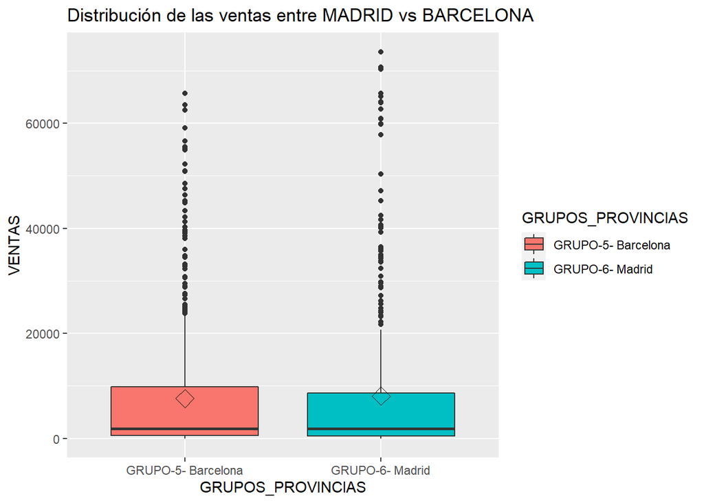

```r
box_ventasMB <- ggplot(data = Ventas_Madrid_Barcelona, aes(x=GRUPOS_PROVINCIAS, y=VENTAS))
box_ventasMB+geom_boxplot(aes(fill=GRUPOS_PROVINCIAS))+
  ylab("VENTAS")+ggtitle("Distribución de las ventas entre MADRID vs BARCELONA")+
  stat_summary(fun.y=mean, geom="point", shape=5, size=4)
```

Si tenemos en cuenta las ventas totales, Barcelona ha vendido un total de 331439 más que Madrid, si bien, Barcelona cuenta con 73 franquicias más que Madrid.

```r
outMadrid <- boxplot.stats(datos_Madrid$VENTAS)
outMadrid
```

```
## $stats
## [1]     5.802   451.187  1827.711  8622.337 20708.096
##
## $n
## [1] 473
##
## $conf
## [1] 1234.089 2421.333
##
## $out
##  [1] 65098.45 23416.27 42466.60 62681.98 34691.54 24773.26 57779.14 25568.86
##  [9] 41682.87 23179.68 29747.00 36119.52 21698.62 30885.86 34422.94 59782.56
## [17] 70694.00 33738.00 34801.85 33616.32 28993.82 22226.19 60838.69 35616.04
## [25] 59882.83 23226.51 29677.79 65638.20 24123.92 63899.88 35010.99 32371.00
## [33] 23969.31 40457.23 39241.85 73605.16 39279.37 45222.40 40054.15 64082.12
## [41] 28655.83 60861.34 29578.66 35934.59 27192.58 34252.12 40408.42 24330.11
## [49] 28816.68 28942.98 28755.38 40653.66 36434.87 59786.32 70280.18 47114.82
## [57] 50312.77 26196.90
```

```r
boxplot.stats(datos_Barcelona$VENTAS)
```

```
## $stats
## [1]     4.924   590.051  1855.448  9814.022 23446.867
##
## $n
## [1] 546
##
## $conf
## [1] 1231.744 2479.153
##
## $out
##  [1] 30802.72 28774.09 39060.82 24312.53 39663.20 24658.81 26541.92 29437.86
##  [9] 32736.17 35924.87 25067.35 33183.26 63495.34 26621.14 23795.21 32271.29
## [17] 25467.36 42166.95 62543.55 33205.77 52257.59 50815.81 50905.04 34732.68
## [25] 46373.16 34490.16 44879.74 48529.69 45225.02 55273.90 27293.59 47496.94
## [33] 39147.93 32987.59 54881.71 56600.89 38528.86 27589.63 30609.24 29030.31
## [41] 29494.77 39439.91 38053.66 59088.25 24026.91 40302.05 24999.63 55532.37
## [49] 65683.80 43332.93 41283.49
```

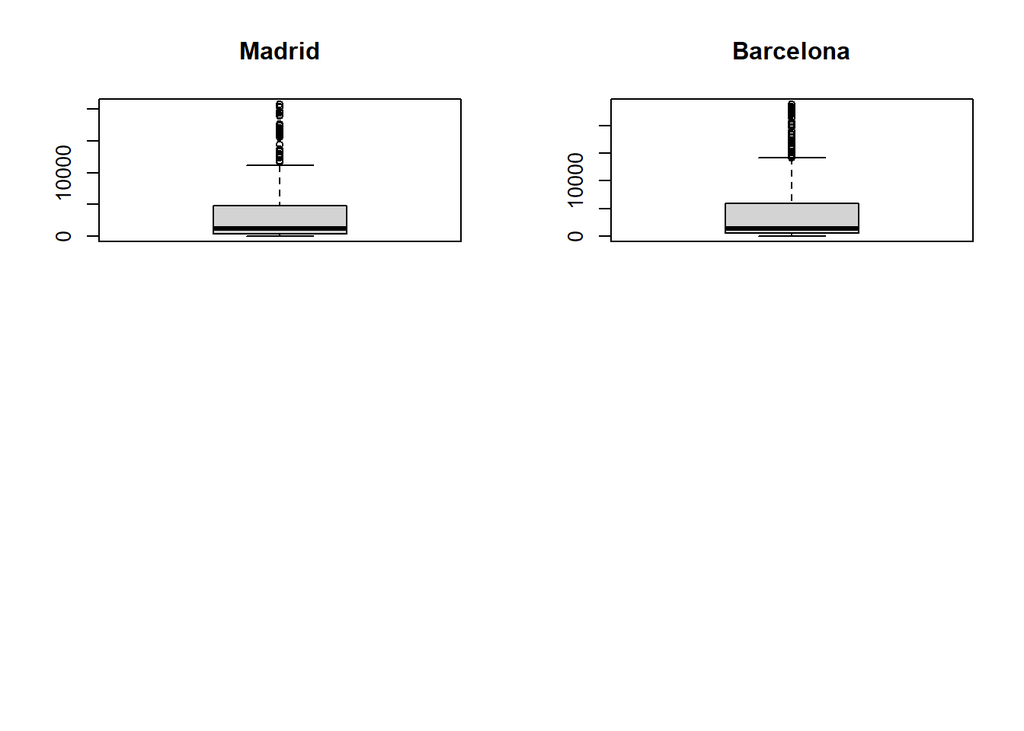

```r
par(mfrow=c(2,2))
outMadrid <- datosVentas_Madrid  |>  filter(VENTAS < 21698)
boxplot(outMadrid, main = "Madrid")
outBarcelona <- datosVentas_Barcelona  |>  filter(VENTAS < 23796)
boxplot(outBarcelona, main = "Barcelona")
```

Aunque no consideremos esos valoes, los resultado siguen siendo unas distribuciones asimétricas positivas, con características similares en Madrid y Barcelona. En cualquier caso, se entiende que la eliminación de los outliers no procede, puesto que disminuiría demasiado el tamaño de la muestra.

##### **5. Presentación del modelo de predicción de las ventas para el siguiente año y describirla adecuadamente.**

En primer lugar voy a realizar el modelo teniendo en cuenta todas las variables, para ver los valores que arroja:

```r
full.model <- lm(VENTAS ~ ., practica)
summary(full.model)
```

```
##
## Call:
## lm(formula = VENTAS ~ ., data = practica)
##
## Residuals:
##    Min     1Q Median     3Q    Max
## -48430  -1451     49   1245  45621
##
## Coefficients:
##                                       Estimate Std. Error t value Pr(>|t|)
## (Intercept)                         -3840.3961   315.4088 -12.176  < 2e-16 ***
## rentabieco                             17.3056     6.0813   2.846 0.004452 **
## rentabifin                              0.5061     1.1344   0.446 0.655518
## endp                                    6.1609     2.3136   2.663 0.007774 **
## liq                                     6.6166    14.0437   0.471 0.637559
## Pdtvidad                               74.3425     3.5841  20.743  < 2e-16 ***
## NºEmp                                 402.9031     4.5011  89.513  < 2e-16 ***
## coe                                 55532.2970  3446.4593  16.113  < 2e-16 ***
## edad                                  -16.0231     9.1201  -1.757 0.079004 .
## conce                                   5.7903     1.6482   3.513 0.000447 ***
## numac                                  69.9956    50.0677   1.398 0.162178
## numpa                                 232.4892   102.2756   2.273 0.023064 *
## numest                                277.1836    63.3551   4.375 1.24e-05 ***
## estpSi                                324.9155   425.7853   0.763 0.445447
## GRUPOS_PROVINCIASGRUPO-2-             140.5716   227.9540   0.617 0.537487
## GRUPOS_PROVINCIASGRUPO-3-            1158.1964   253.2495   4.573 4.93e-06 ***
## GRUPOS_PROVINCIASGRUPO-4-            1608.8774   238.6191   6.742 1.76e-11 ***
## GRUPOS_PROVINCIASGRUPO-5- Barcelona  1917.4053   283.5250   6.763 1.53e-11 ***
## GRUPOS_PROVINCIASGRUPO-6- Madrid     1296.2044   326.0908   3.975 7.15e-05 ***
## ---
## Signif. codes:  0 '***' 0.001 '**' 0.01 '*' 0.05 '.' 0.1 ' ' 1
##
## Residual standard error: 4639 on 4384 degrees of freedom
## Multiple R-squared:  0.8284, Adjusted R-squared:  0.8277
## F-statistic:  1176 on 18 and 4384 DF,  p-value: < 2.2e-16
```

El modelo con todas las variables introducidas como predictores tiene un R-squared de 0.82, es capaz de explicar el 82% de la variabilidad observada en las Ventas. Se aprecia como algunas de las variables no son significativas, por lo que no contribuyen al modelo.

**Mediante el stepAIC veremos el mejor subset para el total de variables:**

```r
step.model <- stepAIC (full.model, direction = "both", trace = FALSE)
summary(step.model)
```

```
##
## Call:
## lm(formula = VENTAS ~ rentabieco + endp + Pdtvidad + NºEmp +
##     coe + edad + conce + numpa + numest + GRUPOS_PROVINCIAS,
##     data = practica)
##
## Residuals:
##    Min     1Q Median     3Q    Max
## -48351  -1438     55   1242  46205
##
## Coefficients:
##                                      Estimate Std. Error t value Pr(>|t|)
## (Intercept)                         -3769.877    306.025 -12.319  < 2e-16 ***
## rentabieco                             17.138      6.073   2.822 0.004797 **
## endp                                    5.797      2.274   2.549 0.010830 *
## Pdtvidad                               74.641      3.572  20.898  < 2e-16 ***
## NºEmp                                 403.417      4.460  90.454  < 2e-16 ***
## coe                                 56121.812   3425.511  16.383  < 2e-16 ***
## edad                                  -14.634      8.990  -1.628 0.103644
## conce                                   5.833      1.647   3.541 0.000403 ***
## numpa                                 251.996    101.584   2.481 0.013150 *
## numest                                293.892     60.817   4.832 1.40e-06 ***
## GRUPOS_PROVINCIASGRUPO-2-             160.746    227.502   0.707 0.479872
## GRUPOS_PROVINCIASGRUPO-3-            1159.326    253.034   4.582 4.74e-06 ***
## GRUPOS_PROVINCIASGRUPO-4-            1603.076    238.319   6.727 1.96e-11 ***
## GRUPOS_PROVINCIASGRUPO-5- Barcelona  1916.156    283.353   6.762 1.54e-11 ***
## GRUPOS_PROVINCIASGRUPO-6- Madrid     1311.181    325.777   4.025 5.80e-05 ***
## ---
## Signif. codes:  0 '***' 0.001 '**' 0.01 '*' 0.05 '.' 0.1 ' ' 1
##
## Residual standard error: 4639 on 4388 degrees of freedom
## Multiple R-squared:  0.8283, Adjusted R-squared:  0.8278
## F-statistic:  1512 on 14 and 4388 DF,  p-value: < 2.2e-16
```

```
+ El mejor modelo resultante del proceso de selección ha sido:
  VENTAS ~ rentabieco + endp + Pdtvidad + NºEmp +
  coe + edad + conce + numpa + numest + GRUPOS_PROVINCIAS
```

con un R-squared del 0.82.

**Mi modelo de predicción:** **MODELO 1:**

En principio las ventas tienen que ver con factores de actividad, con el número de establecimientos y con el empleo.

Ajustamos la regresión, prescindiendo de aquellas variables que son menos significativas, y a mayores prescinciendo de algunas mas que vimos que podian interferir en el modedo de predicción según las correlaciones vistas entre las variables;

He tenido en cuenta aquellas variables independientes más correlacionadas con las Ventas pero sin que estén correlacionadas entre sí: Nº de empleados, Productividad, coe, rentabieco.

No he tenido en cuenta aquellas variables que, como ya vimos, correlacionaban mucho entre si: * el nivel de endeudamiento (endp) y la liquidez(liq) * el nº de participados (numpa), correlacionaba con nº de empleados * el nº de establecimientos por empresa (numest), correlacionaba con nº de empleados. * el nº de accionistas (numac), correlacionaba con nº de empleados y coe. * la edad de las franquicias, correlacionaba con el nº de empleados y coe.

Tengo en cuenta la bbdd con los valores que he normalizado (practica_log):

```r
modelo1 <- (lm (VENTAS ~ Pdtvidad + rentabieco + coe + numest + NºEmp, practica_log))
summary(modelo1)
```

```
##
## Call:
## lm(formula = VENTAS ~ Pdtvidad + rentabieco + coe + numest +
##     NºEmp, data = practica_log)
##
## Residuals:
##     Min      1Q  Median      3Q     Max
## -5.5891 -0.3945  0.0091  0.4339  2.7633
##
## Coefficients:
##              Estimate Std. Error t value Pr(>|t|)
## (Intercept) 7.6429455  0.0695447 109.900  < 2e-16 ***
## Pdtvidad    0.0214418  0.0005551  38.629  < 2e-16 ***
## rentabieco  0.0036045  0.0007607   4.739 2.22e-06 ***
## coe         0.3388772  0.0073723  45.966  < 2e-16 ***
## numest      0.1931451  0.0217241   8.891  < 2e-16 ***
## NºEmp       0.7606392  0.0123306  61.687  < 2e-16 ***
## ---
## Signif. codes:  0 '***' 0.001 '**' 0.01 '*' 0.05 '.' 0.1 ' ' 1
##
## Residual standard error: 0.6609 on 4397 degrees of freedom
## Multiple R-squared:  0.8644, Adjusted R-squared:  0.8643
## F-statistic:  5606 on 5 and 4397 DF,  p-value: < 2.2e-16
```

De lo analizado podemos concluir que:

- El modelo con las 5 variables introducidas como predictores es capaz de explicar el 86.44% de la varianza observada en las Ventas (R² ajustado = 0,8643).
- El estadístico F general del modelo es 5606 y el p-value del modelo es significativo (2.2e-16), por lo que podemos decir que el modelo es útil y que existe una relación entre los predictores y la variable Ventas (al menos uno de los coeficientes es distinto a 0).
- Los 5 predictores que hemos seleccionado parecen tener una relación estadísticamente significativa con la ventas.

Mostramos el intervalo de confianza para cada uno de los coeficientes parciales de regresión:

```r
confint(modelo1)
```

```
##                   2.5 %      97.5 %
## (Intercept) 7.506602921 7.779288172
## Pdtvidad    0.020353611 0.022530052
## rentabieco  0.002113201 0.005095787
## coe         0.324423818 0.353330640
## numest      0.150554875 0.235735306
## NºEmp       0.736464990 0.784813331
```

Con un nivel de confiazza del 95%, por cada unidad que aumenta cada predictor, las Ventas varían en promedio tantas unidades como indica la pendiente.

**Verificamos los supuestos de lo residuos:**

**Comprobamos la multicolinealidad de nuestro modelo 1.**

Debemos revisar la correlación entre las variables independientes. Realizamos el estadístico VIF.

```r
car::vif(modelo1)
```

```
##   Pdtvidad rentabieco        coe     numest      NºEmp
##   1.266595   1.047623   2.367708   1.280182   2.648996
```

Al ser valores < 5 nuestro modelo no presenta multicolinealidad.

**Comprobamos la *normalidad de los residuos* en nuestro modelo 1.**

Los residuos deben distribuirse de forma normal.

```r
shapiro.test(modelo1$residuals)
```

```
##
##  Shapiro-Wilk normality test
##
## data:  modelo1$residuals
## W = 0.98112, p-value < 2.2e-16
```

La falta de normalidad tiene poca influencia si el número de datos es suficientemente grande (TCL).

**Comprobamos la homocedasticidad de los residuos_ en nuestro modelo 1.**

La homocedasticidad se detecta cuando la varianza de los residuos es constante. Cuanto mas constante y pequeña sea una varianza el modelo de predicción será más fiable.

```r
bptest(modelo1)
```

```
##
##  studentized Breusch-Pagan test
##
## data:  modelo1
## BP = 697.39, df = 5, p-value < 2.2e-16
```

Dado que el valor p-valor es menor que 0.05, rechazamos la Ho. No existe homocedasticidad; en este caso los errores estándar que se muestran en la tabla de salida de la regresión pueden no ser confiables.

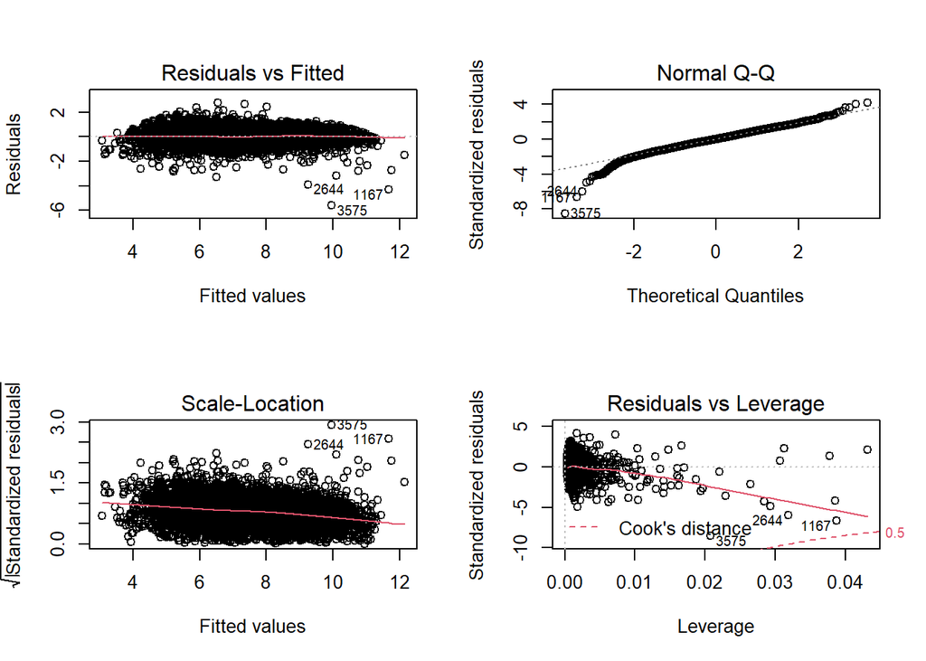

```r
par(mfrow = c(2, 2))
plot(modelo1)
```

Revisando los datos y las gráficas podemos concluir que:

- Los residuos no se distribuyen de forma homogénea en torno a 0. El test de Breusch-Pagan también proporciona evidencias de falta de homocedasticidad (p-valor = 2.2e-16).
- El Q-Q plot refleja que hay indicios de falta de normalidad en los residuos (aquellos de mayor valor), corroborado también por el test de hipótesis de Shapiro Wilk (p-valor = 2.2e-16).
- Existen observaciones con influencia.
- Las variables que incluye el modelo no están correlacionadas.
- Este modelo 1 puede explicar con un 86% la variabilidad en las ventas, el test F muestra que es significativo; ahora bien, atendiendo al estudio de los residuos, puede presentar inconsistencias al no cumplir con los 3 requisitos para los residuos).
- En este modelo 1: el parámetro sería en qué % varían las Ventas(log) cuando se incrementa el un 1% el NºEmp (log). O en qué % varían las Ventas (log), cuando varía en 1 unidad la Pdtvidad.

  $$modelo 1 : Ventas = 7.6429455 +
  0.0214418Pdtvidad + 0.0036045rentabieco + 0.3388772coe
  + 0.1931451numest + 0.7606392NºEmp$$

Veamos si modificando o prescindiendo de alguna de las variables independientes conseguir solventar esa debilidad de nuestro modelo 1.

**MODELO 2:**

Veamos si prescindiendo de la rentabilidad económica, que vimos en el modelo entero que tenia menos significancia y del nº de establecimientos, que correlacionan con las Ventas y el nº de empleados, podemos obtener un modelo que solvente las debilidades del modelo 1 en cuanto a los residuos:

```r
modelo2 <- (lm (VENTAS ~ NºEmp + Pdtvidad + coe, practica_log))
summary(modelo2)
```

```
##
## Call:
## lm(formula = VENTAS ~ NºEmp + Pdtvidad + coe, data = practica_log)
##
## Residuals:
##     Min      1Q  Median      3Q     Max
## -5.4929 -0.3753  0.0122  0.4318  2.9823
##
## Coefficients:
##              Estimate Std. Error t value Pr(>|t|)
## (Intercept) 7.6615523  0.0702233  109.10   <2e-16 ***
## NºEmp       0.7983793  0.0117894   67.72   <2e-16 ***
## Pdtvidad    0.0218888  0.0005595   39.12   <2e-16 ***
## coe         0.3431296  0.0074158   46.27   <2e-16 ***
## ---
## Signif. codes:  0 '***' 0.001 '**' 0.01 '*' 0.05 '.' 0.1 ' ' 1
##
## Residual standard error: 0.6684 on 4399 degrees of freedom
## Multiple R-squared:  0.8613, Adjusted R-squared:  0.8612
## F-statistic:  9104 on 3 and 4399 DF,  p-value: < 2.2e-16
```

De lo analizado podemos concluir que:

- El modelo con las 3 variables introducidas como predictores es capaz de explicar el 86.13% de la varianza observada en las Ventas (R² ajustado = 0,8612).
- El estadístico F general del modelo es 9104 y el p-value del modelo es significativo (2.2e-16), por lo que podemos decir que el modelo es útil y que existe una relación entre los predictores y la variable Ventas (al menos uno de los coeficientes es distinto a 0).
- Los 3 predictores que hemos seleccionado parecen tener una relación estadísticamente significativa con la ventas.

Mostramos el intervalo de confianza para cada uno de los coeficientes parciales de regresión:

```r
confint(modelo2)
```

```
##                  2.5 %     97.5 %
## (Intercept) 7.52387920 7.79922540
## NºEmp       0.77526613 0.82149256
## Pdtvidad    0.02079202 0.02298568
## coe         0.32859082 0.35766835
```

Con un nivel de confiazza del 95%, por cada unidad que aumenta cada predictor, las Ventas varían en promedio tantas unidades como indica la pendiente.

En este caso, por cada 1% que aumenta el predictor NºEmp, por ejemplo, las ventas aumentan en promedio 0.7983 %, manteniéndose constantes el resto de predictores. Con una confianza del 95%, la pendiente se encuentra entre 0.775 y 0.821. Poco probable que el verdadero valor sea 0.

**Verificamos los supuestos de lo residuos:**

**Comprobamos la multicolinealidad de nuestro modelo 2.**

Debemos revisar la correlación entre las variables independientes. Realizamos el estadístico VIF.

```r
car::vif(modelo2)
```

```
##    NºEmp Pdtvidad      coe
## 2.367916 1.258203 2.342662
```

Al ser valores < 5 nuestro modelo no presenta multicolinealidad.

**Comprobamos la *normalidad de los residuos* en nuestro modelo 2.**

Los residuos deben distribuirse de forma normal.

```r
shapiro.test(modelo2$residuals)
```

```
##
##  Shapiro-Wilk normality test
##
## data:  modelo2$residuals
## W = 0.98062, p-value < 2.2e-16
```

Al igual que en el modelo 1, el modelo 2 presenta ausencia de normalidad; nos apoyaremos nuevamente en la TCL.

**Comprobamos la homocedasticidad de los residuos_ en nuestro modelo 2.**

```r
bptest(modelo2)
```

```
##
##  studentized Breusch-Pagan test
##
## data:  modelo2
## BP = 700.64, df = 3, p-value < 2.2e-16
```

Dado que el valor p-valor es menor que 0.05, rechazamos la Ho. No existe homocedasticidad.

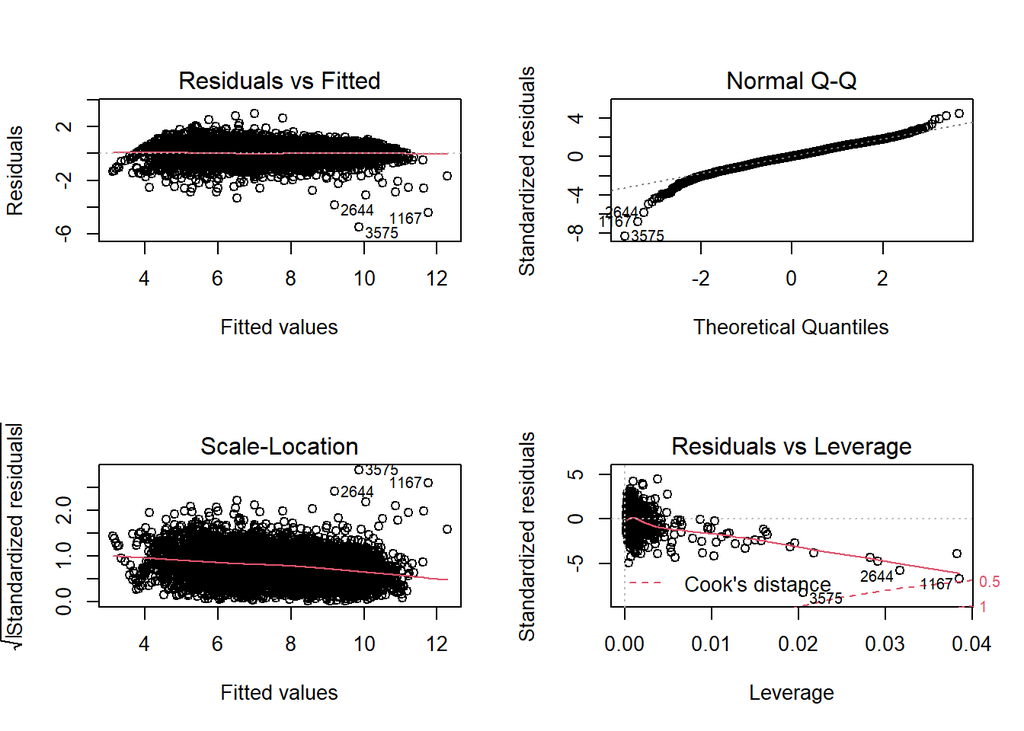

```r
par(mfrow = c(2, 2))
plot(modelo2)
```

Revisando los datos y las gráficas podemos concluir que:

- Los residuos no se distribuyen de forma homogénea en torno a 0. El test de Breusch-Pagan también proporciona evidencias de falta de homocedasticidad (p-valor = 2.2e-16).
- El Q-Q plot refleja que hay indicios de falta de normalidad en los residuos (aquellos de mayor valor), corroborado también por el test de hipótesis de Shapiro Wilk (p-valor = 2.2e-16).
- Existen observaciones con influencia.
- Las variables que incluye el modelo no están correlacionadas.
- Este modelo 2 puede explicar con un 86% la variabilidad en las ventas, el test F muestra que es significativo; ahora bien, atendiendo al estudio de los residuos, puede presentar inconsistencias al no cumplir con los 3 requisitos para los residuos.

Este modelo 2 puede explicar con un 86% la variabilidad en las ventas, el test F muestra que es significativo; a Al igual que con el modelo 1, puede verse afectado por los residuos.

Con respecto al modelo con todas las variables, tanto el modelo 1 como el modelo 2 han incrementado el R² ajustado.

Ambos modelos pueden explicar con un 86% la variabilidad en las ventas, no existen grandes diferencias entre ellos, si bien el modelo 2 alcanza el mismo valor de explicación con menos variables independientes (3 vs 5), lo que lo hace más sencillo; el RMSE para ambos es similar ( 0.6609 con df4397 vs 0.6684 df4399).

Considero quedarme con el **modelo 2**, por lo arriba expuesto. Ahora bien, habría que obtener más información sobre los valores de influencia para saber si se podrían realmente prescindir de ellos y si así se conseguiría mayor consistencia en los residuos y conseguir un modelo más robusto para predecir las Ventas.